# PA1_Template

## Loading and preprocessing the data

```r
setwd("E:\\iitm\\tutorials\\cousera\\DATA\ SCIENTISTS\\5.\ Reproducable\ Research\\Assignment\ 1")
a <- read.csv("activity.csv")
b <- a[!is.na(a$steps),]
```

## What is mean total number of steps taken per day?

```r
library(plyr)
```

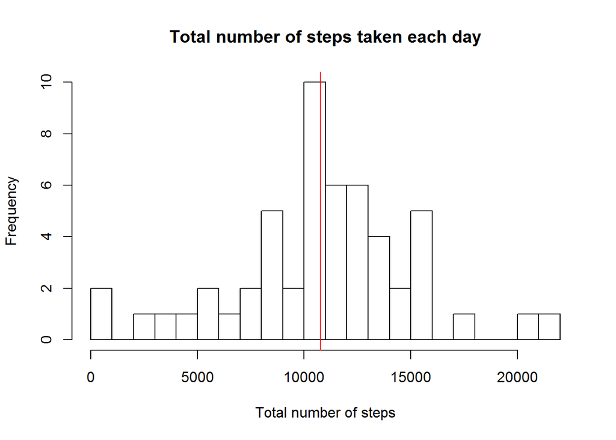

```r
q <- ddply(b,.(date),summarize,sum=sum(steps),mean=mean(steps),median=median(steps))
hist(q$sum,main="Total number of steps taken each day",xlab="Total number of steps",n=20)


abline(v=mean(q$sum),col="blue")
abline(v=median(q$sum),col="red")
```

```r
mean(q$sum)
```

```
## [1] 10766.19
```

```r
median(q$sum)
```

```
## [1] 10765
```

```r
q
```

```
##          date   sum       mean median
## 1  2012-10-02   126  0.4375000      0
## 2  2012-10-03 11352 39.4166667      0
## 3  2012-10-04 12116 42.0694444      0
## 4  2012-10-05 13294 46.1597222      0
## 5  2012-10-06 15420 53.5416667      0
## 6  2012-10-07 11015 38.2465278      0
## 7  2012-10-09 12811 44.4826389      0
## 8  2012-10-10  9900 34.3750000      0
## 9  2012-10-11 10304 35.7777778      0
## 10 2012-10-12 17382 60.3541667      0
## 11 2012-10-13 12426 43.1458333      0
## 12 2012-10-14 15098 52.4236111      0
## 13 2012-10-15 10139 35.2048611      0
## 14 2012-10-16 15084 52.3750000      0
```

[output cut: 39 more lines]

## What is the average daily activity pattern?

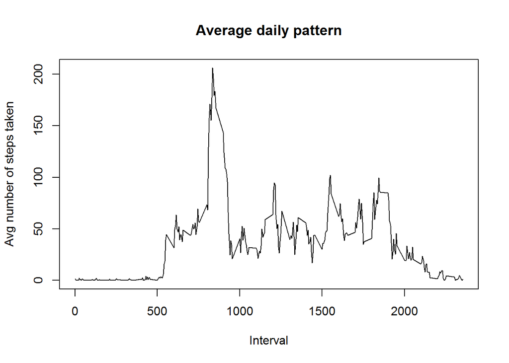

```r
 w <- ddply(b,.(interval),summarize,sum=sum(as.numeric(as.character(steps))),mean=mean(as.numeric(as.character(steps))),median=median(as.numeric(as.character(steps))))

 plot(as.numeric(as.character(w$interval)),as.numeric(as.character(w$mean)),type="l",main="Average daily pattern", xlab="Interval", ylab="Avg number of steps taken")
```

```r
max = max(w$mean)
```

```r
max
```

```
## [1] 206.1698
```

## Imputing missing values

#### 1. Calculate and report the total number of missing values in the dataset (i.e. the total number of rows with NAs)

```r
diff = dim(a)[1]-dim(b)[1]
```

Total number of missing values in the data set is 2304.

#### 2. Devise a strategy for filling in all of the missing values in the dataset. The strategy does not need to be sophisticated. For example, you could use the mean/median for that day, or the mean for that 5-minute interval, etc.

###### We can do that by filling the missing values with mean of steps of that day

#### 3. Create a new dataset that is equal to the original dataset but with the missing data filled in.

```r
len = dim(a)[1]

c <- merge(q,a)
for(i in 1:len)
  if(is.na(c[i,5]))
    c[i,5]=c[i,3]
head(c)
```

```
##         date sum   mean median steps interval
## 1 2012-10-02 126 0.4375      0     0     1740
## 2 2012-10-02 126 0.4375      0     0     1715
## 3 2012-10-02 126 0.4375      0     0     1725
## 4 2012-10-02 126 0.4375      0     0     1710
## 5 2012-10-02 126 0.4375      0     0     1735
## 6 2012-10-02 126 0.4375      0     0     1855
```

```r
dim(c)
```

```
## [1] 17568     6
```

#### 4.Make a histogram of the total number of steps taken each day and Calculate and report the mean and median total number of steps taken per day.

```r
q2 <- ddply(c,.(date),summarize,sum=sum(steps),mean=mean(steps),median=median(steps))

dim(q2)
```

```
## [1] 54  4
```

```r
head(q2)
```

```
##         date   sum     mean median
## 1 2012-10-02   126  0.43750      0
## 2 2012-10-03 11352 39.41667      0
## 3 2012-10-04 12116 42.06944      0
## 4 2012-10-05 13294 46.15972      0
## 5 2012-10-06 15420 53.54167      0
## 6 2012-10-07 11015 38.24653      0
```

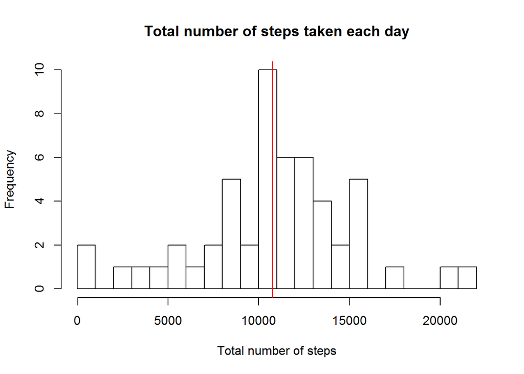

```r
hist(q2$sum , main = "Total number of steps taken each day" , xlab = "Total number of steps" , n=20)
abline(v=mean(q$sum),col="blue")
abline(v=median(q$sum),col="red")
```

```r
mean(q$sum)
```

```
## [1] 10766.19
```

```r
median(q$sum)
```

```
## [1] 10765
```

## Are there differences in activity patterns between weekdays and weekends?

#### 1. Create a new factor variable in the dataset with two levels - “weekday” and “weekend” indicating whether a given date is a weekday or weekend day

```r
library(chron)
c <- mutate(c ,factor = factor(!is.weekend(c$date) , labels = c("weekend", "weekday")))

head(c)
```

```
##         date sum   mean median steps interval  factor
## 1 2012-10-02 126 0.4375      0     0     1740 weekday
## 2 2012-10-02 126 0.4375      0     0     1715 weekday
## 3 2012-10-02 126 0.4375      0     0     1725 weekday
## 4 2012-10-02 126 0.4375      0     0     1710 weekday
## 5 2012-10-02 126 0.4375      0     0     1735 weekday
## 6 2012-10-02 126 0.4375      0     0     1855 weekday
```

#### 2. Make a panel plot containing a time series plot (i.e. type = “l”) of the 5-minute interval (x-axis) and the average number of steps taken, averaged across all weekday days or weekend days (y-axis). See the README file in the GitHub repository to see an example of what this plot should look like using simulated data.

```r
d <- c[as.character(c$factor)=="weekday",]

wd <- ddply(d,.(interval),summarize,sum=sum(as.numeric(as.character(steps))),mean=mean(as.numeric(as.character(steps))),median=median(as.numeric(as.character(steps))))

e <- c[as.character(c$factor)=="weekend",]

 we <- ddply(d,.(interval),summarize,sum=sum(as.numeric(as.character(steps))),mean=mean(as.numeric(as.character(steps))),median=median(as.numeric(as.character(steps))))
```

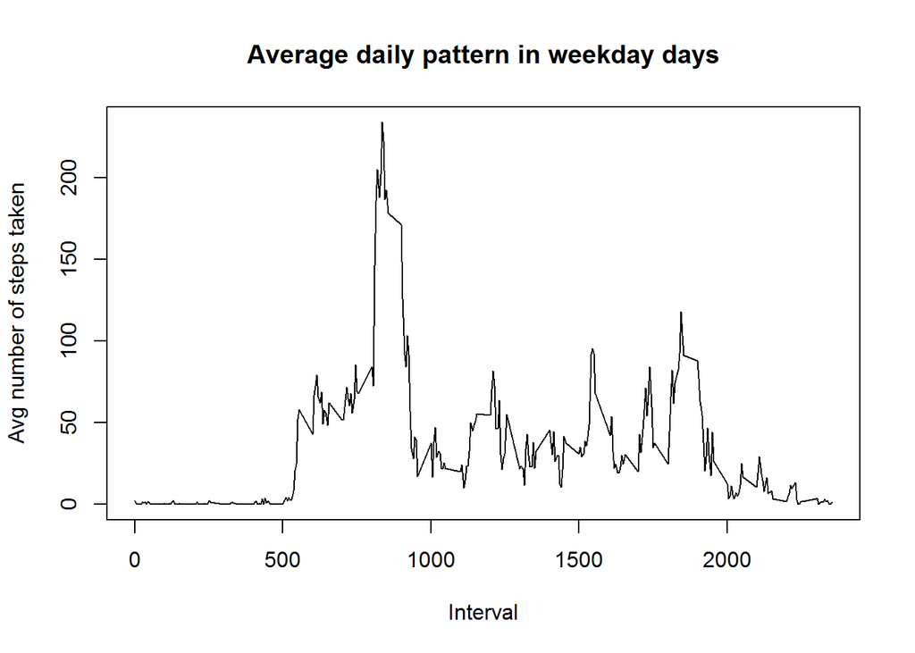

```r
plot(as.numeric(as.character(wd$interval)),as.numeric(as.character(wd$mean)),type="l",main="Average daily pattern in weekday days", xlab="Interval", ylab="Avg number of steps taken")
```

[figure not shown]

```r
plot(as.numeric(as.character(we$interval)),as.numeric(as.character(we$mean)),type="l",main="Average daily pattern in weekend days", xlab="Interval", ylab="Avg number of steps taken")
```